# chap8_axes

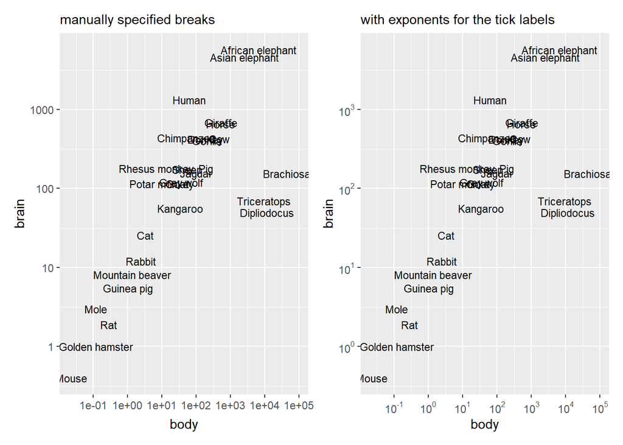

```r
fig_8271 <-
  Animals %>%
  ggplot(aes(x = body, y = brain, label = rownames(Animals))) +
  geom_text(size = 3) +
  scale_x_log10(breaks = 10^(-1:5)) +
  scale_y_log10(breaks = 10^(0:3)) +
  labs(subtitle = "manually specified breaks")

fig_8272 <-
  Animals %>%
  ggplot(aes(x = body, y = brain, label = rownames(Animals))) +
  geom_text(size = 3) +
  scale_x_log10(breaks = 10^(-1:5),
                labels = scales::trans_format("log10", scales::math_format(10^.x))) +
  scale_y_log10(breaks = 10^(0:3),
                labels = scales::trans_format("log10", scales::math_format(10^.x))) +
  labs(subtitle = "with exponents for the tick labels")

fig_8271 + fig_8272
```

log변환을 하는 다른 방법은 데이터를 로그변환 시키는 방법이 있다.

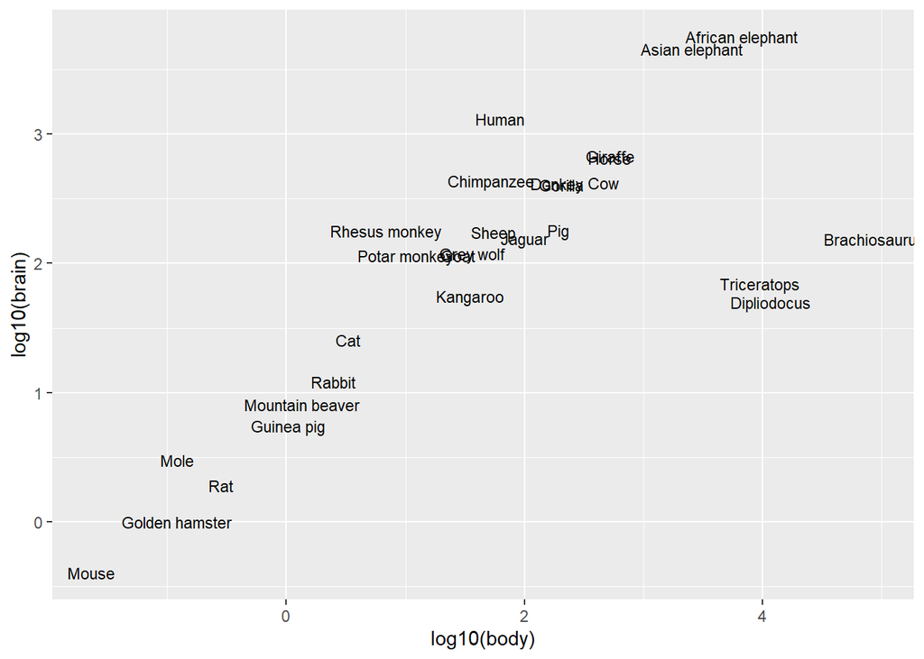

```r
Animals %>%
  ggplot(aes(x = log10(body), y = log10(brain), label = rownames(Animals))) +
  geom_text(size = 3)
```

자연로그를 사용하기 위해서는 `scale`package가 필요하다.

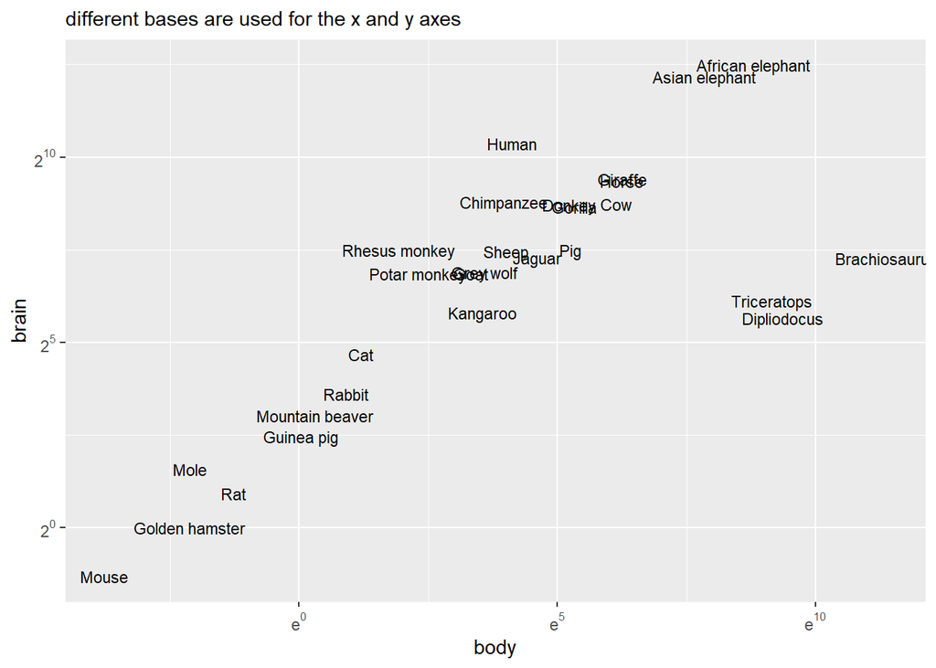

```r
Animals %>%
  ggplot(aes(x = body, y = brain, label = rownames(Animals))) +
  geom_text(size = 3) +
  scale_x_continuous(trans = scales::log_trans(),
                     breaks = scales::trans_breaks("log", function(x) exp(x)),
                     labels = scales::trans_format("log", scales::math_format(e^.x))) +
  scale_y_continuous(trans = scales::log2_trans(),
                     breaks = scales::trans_breaks("log2", function(x) 2^x),
                     labels = scales::trans_format("log2", scales::math_format(2^.x))) +
  labs(subtitle = "different bases are used for the x and y axes")
```

한 축에만 로그를 쓰는 것도 가능한데 이건 금융관련 데이터를 보여줄 때 유용하다.

```r
aapl
```

```
##            date  adj_price
## 1    1980-12-12   0.023268
## 2    1980-12-19   0.022863
## 3    1980-12-26   0.028731
## 4    1981-01-02   0.027921
## 5    1981-01-09   0.025797
## 6    1981-01-16   0.025089
## 7    1981-01-23   0.026505
## 8    1981-01-30   0.022863
## 9    1981-02-06   0.023268
## 10   1981-02-13   0.020637
## 11   1981-02-20   0.019626
## 12   1981-02-27   0.021447
## 13   1981-03-06   0.020739
## 14   1981-03-13   0.018007
```

[output cut: 1938 more lines]

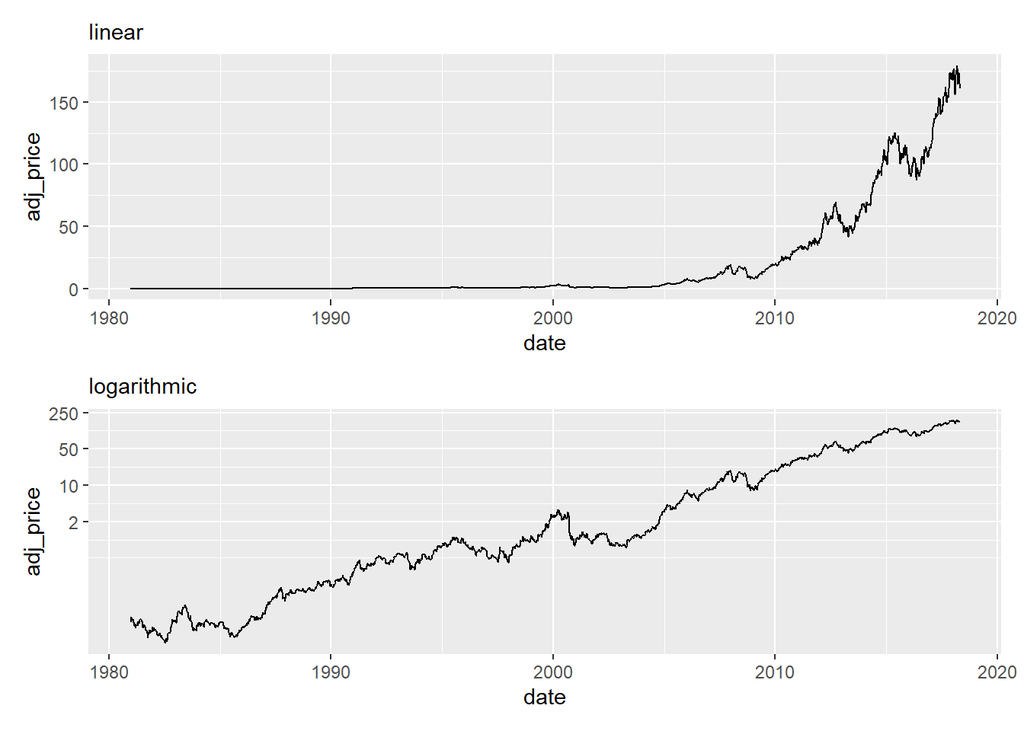

```r
fig_8301 <-
aapl %>%
  ggplot(aes(x = date, y = adj_price)) +
  geom_line() +
  labs(subtitle = "linear")


fig_8302 <-
 aapl %>%
  ggplot(aes(x = date, y = adj_price)) +
  geom_line() +
  scale_y_log10(breaks = c(2, 10, 50, 250)) +
  labs(subtitle = "logarithmic")

fig_8301 / fig_8302
```

### 8.15 Adding ticks for a logarithmic axis

로그가 씌어진 축에 tick mark를 주기 위해서는 `annotate_logticks()`를 사용한다.  
`annotate_logticks()`는 plot area 내부에 그려지는데 긴 tick mark는 10제곱을 나타내며, 짧은 tick mark는 5제곱을 나타낸다.

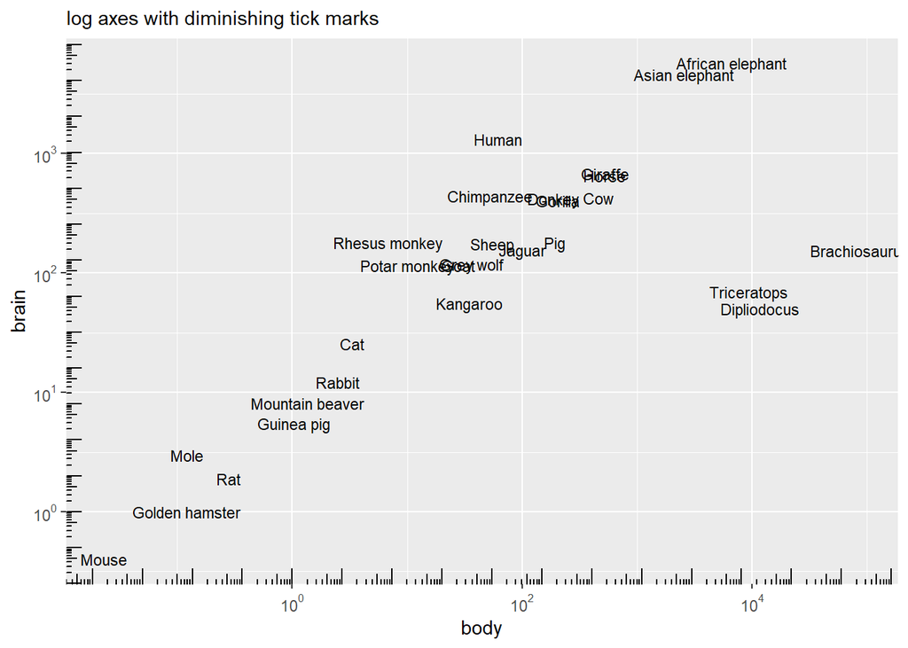

```r
Animals %>%
  ggplot(aes(x = body, y = brain, label = rownames(Animals))) +
  geom_text(size = 3) +
  annotation_logticks() +
  scale_x_continuous(trans = scales::log_trans(),
                     breaks = scales::trans_breaks("log10", function(x) 10^x),
                     labels = scales::trans_format("log10", scales::math_format(10^.x))) +
  scale_y_continuous(trans = scales::log2_trans(),
                     breaks = scales::trans_breaks("log10", function(x) 10^x),
                     labels = scales::trans_format("log10", scales::math_format(10^.x))) +
  labs(subtitle = "log axes with diminishing tick marks")
```

내용을 보기 쉽게 하기 위해 `theme_bw()`를 사용하고 주눈금 사이에 보조눈금을 나타낸다.  
보조눈금은 로그 스케일의 5를 가리키는 tick mark와 같은 의미가 아니라 주눈금의 절반 지점에 위치한다.  
보조눈금을 그릴려면 `scales` package의 `minor_breaks()`를 직접 설정해야 한다.  
`minor_breaks()`는 log10(5 * 10^(minpow:maxpow)를 log10(5) + minpow:maxpow 형식으로 줄여서 나타낸다.

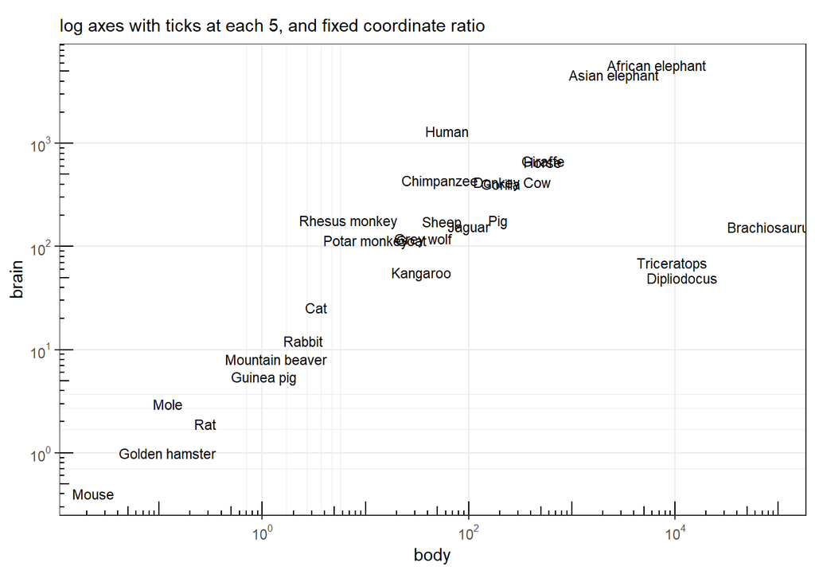

```r
Animals %>%
  ggplot(aes(x = body, y = brain, label = rownames(Animals))) +
  geom_text(size = 3) +
  annotation_logticks() +
  scale_x_log10(breaks = scales::trans_breaks("log10", function(x) 10^x),
                labels = scales::trans_format("log10", scales::math_format(10^.x)),
                minor_breaks = log10(5) + -2:5) +
  scale_y_log10(breaks = scales::trans_breaks("log10", function(x) 10^x),
                labels = scales::trans_format("log10", scales::math_format(10^.x)),
                minor_breaks = log10(5) + -1:3) +
  labs(subtitle = "log axes with ticks at each 5, and fixed coordinate ratio") +
  coord_fixed() +
  theme_bw()
```

### 8.16 Making a circular graph

`coord_polar()`를 사용하면 원그래프를 그릴 수 있다.  
예제로 사용할 `wind` 데이터는 하루동안 5분간격으로 풍향(DirCat)과 풍속(SpeedCat)을 측정한 것이다.  
풍향은 15도 간격으로 범주화가 되어있고, 풍속은 5m/s 단위로 범주화가 되어 있다.

```r
wind
```

```
##     TimeUTC  Temp WindAvg WindMax WindDir SpeedCat DirCat
## 3         0  3.54    9.52   10.39      89    10-15     90
## 4         5  3.52    9.10    9.90      92     5-10     90
## 5        10  3.53    8.73    9.51      92     5-10     90
## 6        15  3.63    8.97    9.90      94     5-10     90
## 7        20  3.71    8.51    9.41      97     5-10     90
## 8        25  3.73    8.43    9.02      95     5-10     90
## 9        30  3.56    8.12    8.92      98     5-10    105
## 10       35  3.63    8.47    9.11     101     5-10    105
## 11       40  3.59    8.27    9.21     101     5-10    105
## 12       45  3.82    8.76    9.41     101     5-10    105
## 13       50  3.78    8.77    9.51      97     5-10     90
## 14       55  3.67    8.24    9.11      96     5-10     90
## 15      100  3.52    8.04    8.62      97     5-10     90
## 16      105  3.57    8.34    9.02      98     5-10    105
```

[output cut: 272 more lines]

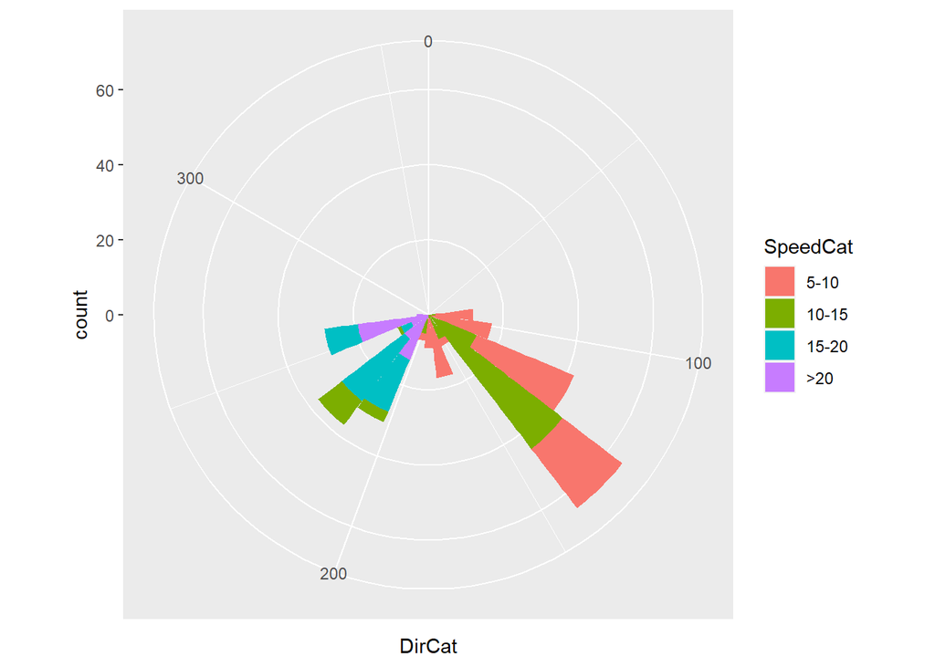

```r
wind %>%
  ggplot(aes(x = DirCat, fill = SpeedCat)) +
  geom_histogram(binwidth = 15, boundary = -7.5) +
  coord_polar() +
  scale_x_continuous(limits = c(0,360))
```

식별하기 쉽게 범례를 거꾸로 배열하고 다른 팔레트를 사용하고, 아웃라인을 추가한다.  
구분자는 익숙한 숫자로 바꾼다.

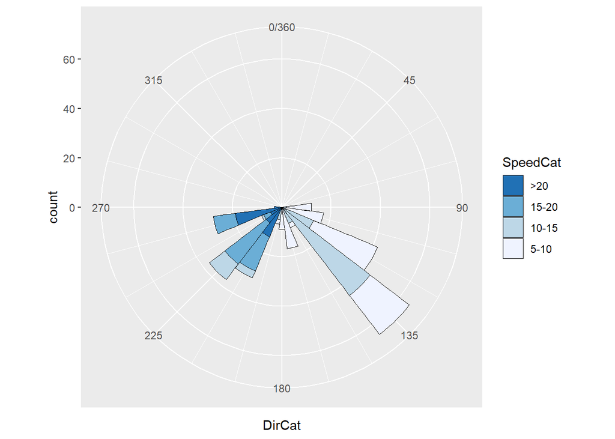

```r
wind %>%
  ggplot(aes(x = DirCat, fill = SpeedCat)) +
  geom_histogram(binwidth = 15, boundary = -7.5, color = "#000000", size = 0.25) +
  guides(fill = guide_legend(reverse = TRUE)) +
  coord_polar() +
  scale_x_continuous(limits = c(0,360),
                     breaks = seq(0,360, by = 45),
                     minor_breaks = seq(0, 360, by = 15)) +
  scale_fill_brewer()
```

시작되는 angle을 지정하는 `start` argument는 이산형 변수를 사용할 때 유용하게 사용된다.  
시작되는 angle은 라디안으로 나타낸다.  
Polar coordinates도 다른 geom들처럼 선이나 점을 추가할 수 있다.  
이 때 주의할 점은 가장 작은 값이 중앙에 배치된다는 점이다.  
가장 작은 값이 0이면 반경 0 위치에 배치가 되므로 이런 점을 감안하여 limits을 지정해줘야 한다.

연속형의 x값을 쓸 때는 가장 작은 값과 가장 큰 값이 합쳐질 수 있다. 원하든 원치 않든 이런 현상을 바꾸기 위해서는 limits을 설정해야 한다.

마지막으로 polar coordinates의 $theta$는 전체를 둘러싸지 못한다. 즉 시작하는 각도로 지정된 지점을 가로지를 수 없다.

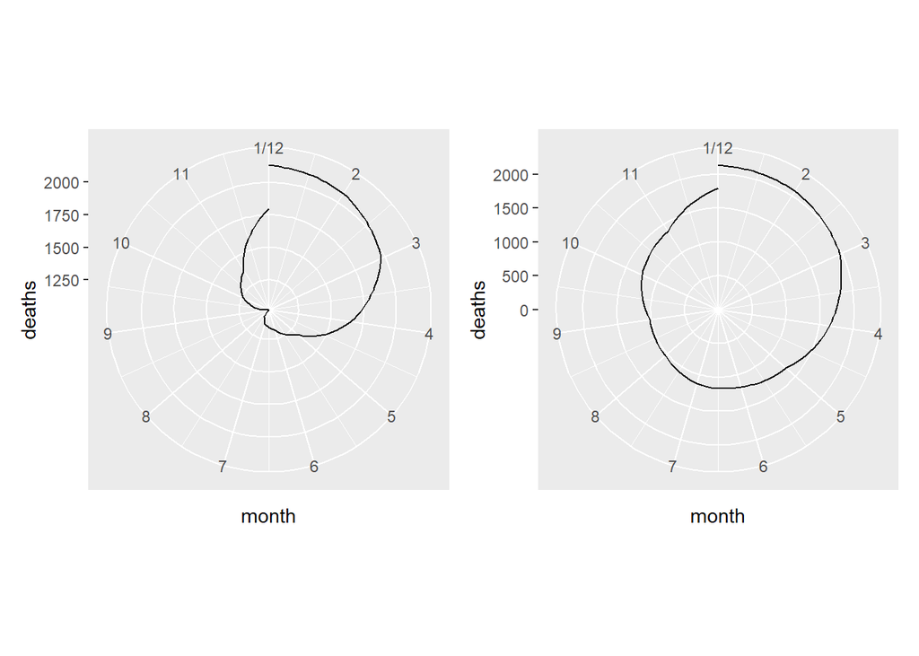

```r
# put mdeaths time series data into a data frame
md <- data.frame(deaths = as.numeric(mdeaths),
                 month = as.numeric(cycle(mdeaths)))

# Calculate average number of deaths in each month
md <-
  md %>%
  group_by(month) %>%
  summarise(deaths = mean(deaths))

# Make the base plot
fig_8351 <-
  md %>%
  ggplot(aes(x = month, y = deaths)) +
  geom_line() +
  scale_x_continuous(breaks = 1:12) +
  coord_polar()


# With coord_polar and y(r) limits going to zero
fig_8352 <-
  md %>%
  ggplot(aes(x = month, y = deaths)) +
  geom_line() +
  scale_x_continuous(breaks = 1:12) +
  coord_polar() +
  ylim(0, max(md$deaths))

fig_8351 + fig_8352
```

첫번째 문제는 데이터가 1000-2100정도의 값을 가지는데 가장 작은 값은 반경 0의 위치에 있다. (8월 데이터)  
따라서 최소값이 0부터 시작하도록 바꿔야 한다. (오른쪽 그림 참조)

두번째 문제는 1월과 12월 - 가장 작은 x값과 가장 큰 x값이 겹쳐서 한 지점에 위치하고 있다. 이를 수정하기 위해서 x축 limits을 0-12까지로 변경해야 한다. `xlim()`을 사용할 경우 `scale_x_continuous()`를 override함에 주의해야 한다.

마지막으로 시작과 끝이 연결되지 않게 해야 한다. 이를 위해서 0월에 해당되는 값을 데이터에 추가해야 하는데 12월과 같은 값을 가지도록 한다.  
0월 대신에 13월을 만들어서 넣는 것도 가능하다.

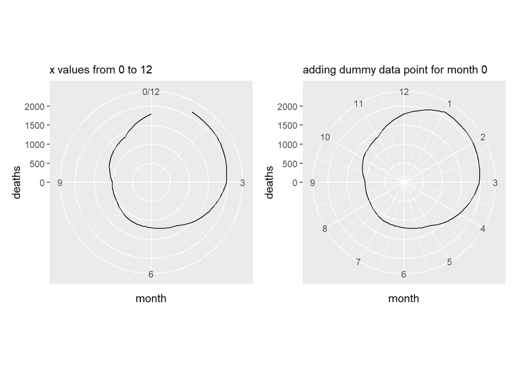

```r
fig_8361 <-
  md %>%
  ggplot(aes(x = month, y = deaths)) +
  geom_line() +
  scale_x_continuous(breaks = 1:12) +
  coord_polar() +
  ylim(0, max(md$deaths)) + xlim(0,12) +
  labs(subtitle = "x values from 0 to 12")
# Connect the lines by adding a value for 0 that is same as 12
mdx <- md[md$month == 12, ]
mdx$month <- 0
mdnew <- rbind(mdx, md)

fig_8362 <-
  mdnew %>%
  ggplot(aes(x = month, y = deaths)) +
  geom_line() +
  scale_x_continuous(breaks = 1:12) +
  coord_polar() +
  ylim(0, max(md$deaths)) +
  labs(subtitle = "adding dummy data point for month 0")

fig_8361 + fig_8362
```

### 8.17 Using dates on an axis

```r
economics
```

```
## # A tibble: 574 x 6
##    date         pce    pop psavert uempmed unemploy
##    <date>     <dbl>  <dbl>   <dbl>   <dbl>    <dbl>
##  1 1967-07-01  507. 198712    12.6     4.5     2944
##  2 1967-08-01  510. 198911    12.6     4.7     2945
##  3 1967-09-01  516. 199113    11.9     4.6     2958
##  4 1967-10-01  512. 199311    12.9     4.9     3143
##  5 1967-11-01  517. 199498    12.8     4.7     3066
##  6 1967-12-01  525. 199657    11.8     4.8     3018
##  7 1968-01-01  531. 199808    11.7     5.1     2878
##  8 1968-02-01  534. 199920    12.3     4.5     3001
##  9 1968-03-01  544. 200056    11.7     4.1     2877
## 10 1968-04-01  544  200208    12.3     4.6     2709
## # ... with 564 more rows
```

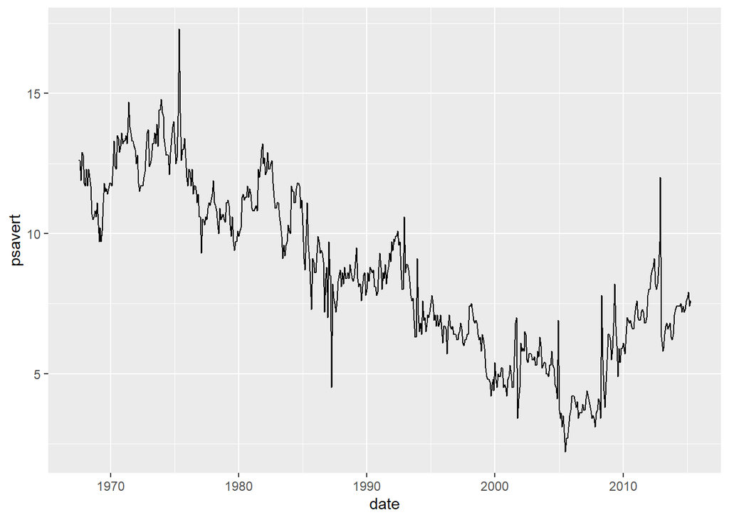

```r
economics %>%
  ggplot(aes(x = date, y = psavert)) +
  geom_line()
```

ggplot2에서는 Date와 POSIXt 두 가지 time related object를 다룰 수 있는데, Date는 1일 단위, POSIXt는 초 단위를 다룰 수 있다.

```r
# Take a subset of economic
econ <- subset(economics,
               date >= as.Date("1992-05-01") &
                 date < as.Date("1993-06-01"))
```

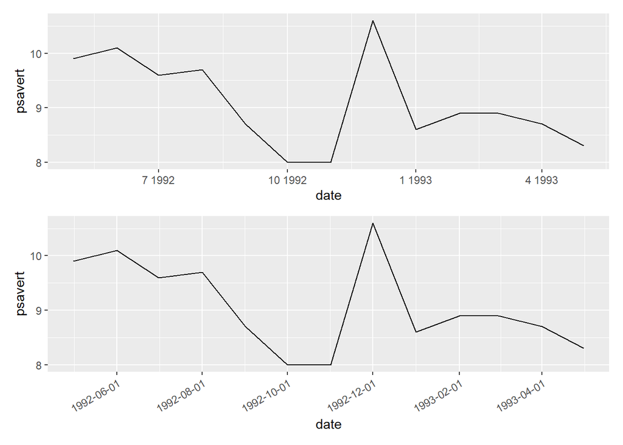

```r
fig_8381 <-
econ %>%
  ggplot(aes(x = date, y = psavert)) +
  geom_line()

# Specify breaks as a Date Vector
datebreaks = seq(as.Date("1992-06-01"), as.Date("1993-06-01"), by = "2 month")

fig_8382 <-
econ %>%
  ggplot(aes(x = date, y = psavert)) +
  geom_line() +
  scale_x_date(breaks = datebreaks) +
  theme(axis.text.x = element_text(angle = 30, hjust = 1))

fig_8381 / fig_8382
```

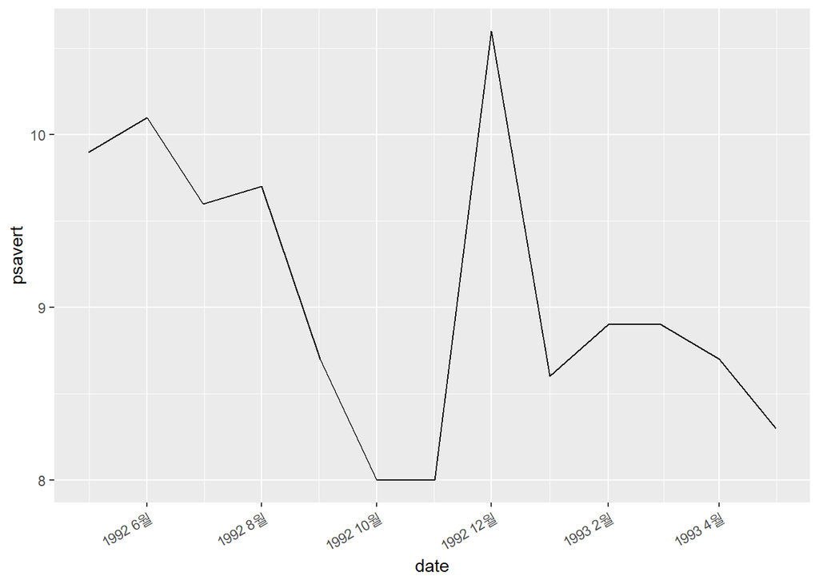

```r
# Specify breaks as a Date Vector
datebreaks = seq(as.Date("1992-06-01"), as.Date("1993-06-01"), by = "2 month")

econ %>%
  ggplot(aes(x = date, y = psavert)) +
  geom_line() +
  scale_x_date(breaks = datebreaks, labels = scales::date_format("%Y %B")) +
  theme(axis.text.x = element_text(angle = 30, hjust = 1))
```

### 8.18 Using relative times on an axis

저장된 숫자가 시간을 의미하는 경우 정해진 때부터 얼마나 시간이 흘렀는지를 표현해야 할 때가 있다.

```r
WWWusage
```

```
## Time Series:
## Start = 1
## End = 100
## Frequency = 1
##   [1]  88  84  85  85  84  85  83  85  88  89  91  99 104 112 126 138 146 151
##  [19] 150 148 147 149 143 132 131 139 147 150 148 145 140 134 131 131 129 126
##  [37] 126 132 137 140 142 150 159 167 170 171 172 172 174 175 172 172 174 174
##  [55] 169 165 156 142 131 121 112 104 102  99  99  95  88  84  84  87  89  88
##  [73]  85  86  89  91  91  94 101 110 121 135 145 149 156 165 171 175 177 182
##  [91] 193 204 208 210 215 222 228 226 222 220
```

```r
# Convert WWWusage time-series object to data frame
www <- data.frame(minute = as.numeric(time(WWWusage)),
                  users = as.numeric(WWWusage))

www
```

```
##     minute users
## 1        1    88
## 2        2    84
## 3        3    85
## 4        4    85
## 5        5    84
## 6        6    85
## 7        7    83
## 8        8    85
## 9        9    88
## 10      10    89
## 11      11    91
## 12      12    99
## 13      13   104
## 14      14   112
```

[output cut: 86 more lines]

```r
# Define a fomatter function - converts time in minutes to a string
timeHM_formatter <- function(x) {
  h <- floor(x / 60)
  m <- floor(x %% 60)
  lab <- sprintf("%d:%02d", h, m) # Format the strings as HH:MM
  return(lab)
}
```

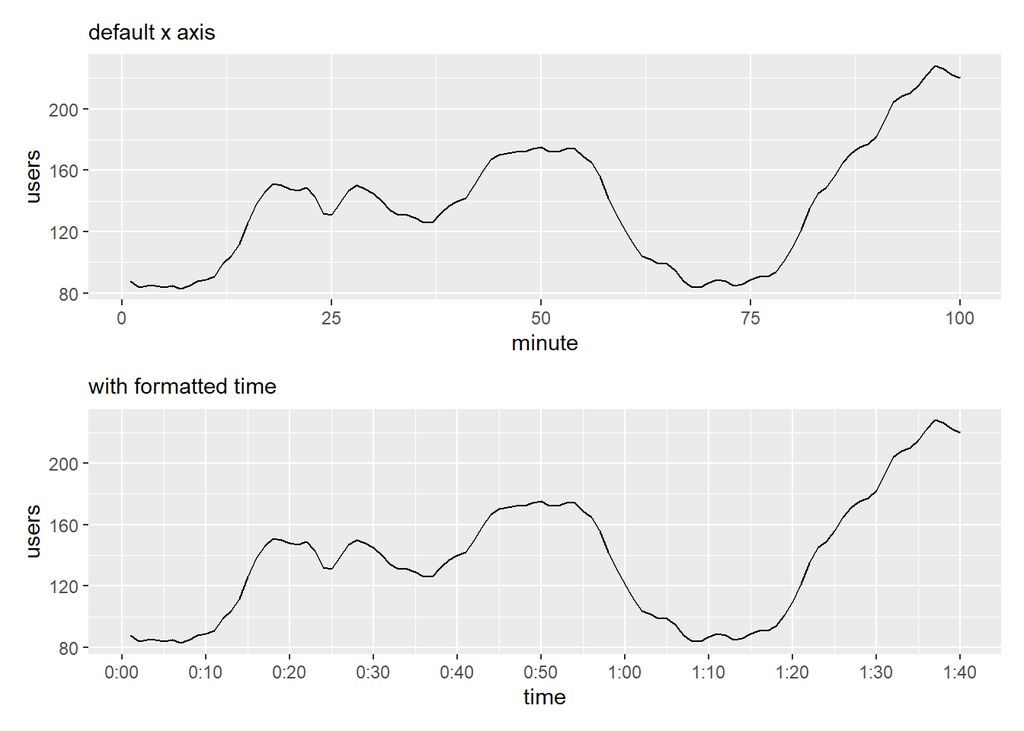

```r
fig_8401 <-
  www %>%
  ggplot(aes(x = minute, y = users)) +
  geom_line() +
  labs(subtitle = "default x axis")

fig_8402 <-
  www %>%
  ggplot(aes(x = minute, y = users)) +
  geom_line() +
  scale_x_continuous(name = "time", breaks = seq(0, 100, by = 10),
                     labels = timeHM_formatter) +
  labs(subtitle = "with formatted time")

fig_8401 / fig_8402
```

**END**